# JSC370_Assignment2

Elaine Dai

2024-02-16

```r
library(tidyverse)
library(stringr)
library(kableExtra)
library(stats)
library(mgcv)
```

## Data Wrangling

### 1. Put the life expectancy data in “tidy” format by creating a new column “Sex”. You may want to use pivot_longer function from the tidyr package.

```r
alcohol <- read.csv("Alcohol.csv")
le <- read.csv("life_expectancy.csv")
```

```r
le <- le %>%
  pivot_longer(
    cols = c(Life.expectancy...Sex..female...Age..at.birth...Variant..estimates, Life.expectancy...Sex..male...Age..at.birth...Variant..estimates),
    names_to = "Sex",
    values_to = "Life_Expectancy",
    names_transform = list(Sex = function(x) str_extract(x, "female|male")),
    values_drop_na = TRUE
  ) %>%
  mutate(Sex = ifelse(Sex == "female", "Female", "Male"))
head(le)
```

[output not shown]

### 2. Filter the alcohol consumption data to exclude rows with data for “Both sexes”.

```r
alcohol <- alcohol %>% filter(Sex != "Both sexes")
head(alcohol)
```

[output not shown]

### 3. For convenience, you may rename any variables which have complicated names.

```r
le <- le %>% rename(Country = Entity, Population_all = Population...Sex..all...Age..all...Variant..estimates)
head(le)
```

```
## # A tibble: 6 × 7
##   Country     Code   Year Population_all Continent Sex    Life_Expectancy
##   <chr>       <chr> <int>          <dbl> <chr>     <chr>            <dbl>
## 1 Afghanistan AFG    1950        7480464 ""        Female            28.4
## 2 Afghanistan AFG    1950        7480464 ""        Male              27.1
## 3 Afghanistan AFG    1951        7571542 ""        Female            28.6
## 4 Afghanistan AFG    1951        7571542 ""        Male              27.4
## 5 Afghanistan AFG    1952        7667534 ""        Female            29.1
## 6 Afghanistan AFG    1952        7667534 ""        Male              27.8
```

```r
alcohol <- alcohol %>%
  rename(
    Region_Code = WHO.Region.Code,
    Region = WHO.Region,
    Country_Code = Country.Code,
    Alcohol_Consumption = Alcohol.total.per.capita..15...consumption.in.liters..numeric.,
    Low_Est. = Alcohol.total.per.capita..15...consumption.in.liters..low.estimation.,
    High_Est. = Alcohol.total.per.capita..15...consumption.in.liters..high.estimation.,
    Alcohol_Consumption_str = Alcohol.total.per.capita..15...consumption.in.liters..string.
  )
head(alcohol)
```

```
##   Region_Code                Region Country_Code    Country Year    Sex
## 1        SEAR       South-East Asia          BGD Bangladesh 2019 Female
## 2        SEAR       South-East Asia          BGD Bangladesh 2019   Male
## 3         EMR Eastern Mediterranean          KWT     Kuwait 2019 Female
## 4         EMR Eastern Mediterranean          KWT     Kuwait 2019   Male
## 5         AFR                Africa          MRT Mauritania 2019 Female
## 6         AFR                Africa          MRT Mauritania 2019   Male
##   Alcohol_Consumption Low_Est. High_Est. Alcohol_Consumption_str
## 1                   0        0         0               0 [0 – 0]
## 2                   0        0         0               0 [0 – 0]
## 3                   0        0         0               0 [0 – 0]
## 4                   0        0         0               0 [0 – 0]
## 5                   0        0         0               0 [0 – 0]
## 6                   0        0         0               0 [0 – 0]
```

### 4. Merge these datasets by country name and year.

```r
data_merged <- inner_join(alcohol, le, by = c("Country", "Year", "Sex"))
head(data_merged)
```

```
##   Region_Code                Region Country_Code    Country Year    Sex
## 1        SEAR       South-East Asia          BGD Bangladesh 2019 Female
## 2        SEAR       South-East Asia          BGD Bangladesh 2019   Male
## 3         EMR Eastern Mediterranean          KWT     Kuwait 2019 Female
## 4         EMR Eastern Mediterranean          KWT     Kuwait 2019   Male
## 5         AFR                Africa          MRT Mauritania 2019 Female
## 6         AFR                Africa          MRT Mauritania 2019   Male
##   Alcohol_Consumption Low_Est. High_Est. Alcohol_Consumption_str Code
## 1                   0        0         0               0 [0 – 0]  BGD
## 2                   0        0         0               0 [0 – 0]  BGD
## 3                   0        0         0               0 [0 – 0]  KWT
## 4                   0        0         0               0 [0 – 0]  KWT
## 5                   0        0         0               0 [0 – 0]  MRT
## 6                   0        0         0               0 [0 – 0]  MRT
##   Population_all Continent Life_Expectancy
## 1      165516220                      75.1
## 2      165516220                      70.7
## 3        4441105                      82.3
## 4        4441105                      78.2
## 5        4383853                      67.7
## 6        4383853                      63.8
```

### 5. Using the kable package, create a summary table showing the mean and sd of life expectancy and alcohol consumption by year, and sex.

```r
summary <- data_merged %>%
  group_by(Year, Sex) %>%
  summarise(
    Mean_Life_Expectancy = mean(Life_Expectancy, na.rm = TRUE),
    SD_Life_Expectancy = sd(Life_Expectancy, na.rm = TRUE),
    Mean_Alcohol_Consumption = mean(Alcohol_Consumption, na.rm = TRUE),
    SD_Alcohol_Consumption = sd(Alcohol_Consumption, na.rm = TRUE),
    .groups = "drop"
  )
kable_output <- kable(summary, "html",
                      caption = "Summary of Life Expectancy and Alcohol Consumption by Year and Sex",
                      position = "right") %>%
  kable_styling("striped", full_width = F) %>%
  column_spec(1:2, width = "15em") %>%
  scroll_box(width = "100%", height = "500px")

kable_output
```

Summary of Life Expectancy and Alcohol Consumption by Year and Sex

| Year | Sex | Mean_Life_Expectancy | SD_Life_Expectancy | Mean_Alcohol_Consumption | SD_Alcohol_Consumption |
| --- | --- | --- | --- | --- | --- |
| 2000 | Female | 69.14036 | 10.571545 | 2.523819 | 2.164264 |
| 2000 | Male | 64.09157 | 9.526031 | 9.235145 | 7.007668 |
| 2001 | Female | 69.44096 | 10.645375 | 2.523819 | 2.164264 |
| 2001 | Male | 64.38735 | 9.517500 | 9.235145 | 7.007668 |
| 2002 | Female | 69.71325 | 10.525493 | 2.518374 | 2.159343 |
| 2002 | Male | 64.67289 | 9.443737 | 9.205151 | 6.992798 |
| 2003 | Female | 69.97952 | 10.466718 | 2.518379 | 2.146989 |
| 2003 | Male | 64.95482 | 9.358519 | 9.192428 | 6.937405 |
| 2004 | Female | 70.26145 | 10.352038 | 2.534066 | 2.126814 |
| 2004 | Male | 65.28072 | 9.277676 | 9.236566 | 6.852761 |
| 2005 | Female | 70.67410 | 10.235689 | 2.568946 | 2.141408 |
| 2005 | Male | 65.61988 | 9.186790 | 9.332512 | 6.862059 |
| 2006 | Female | 71.08133 | 10.076397 | 2.602223 | 2.159834 |
| 2006 | Male | 65.98976 | 9.091239 | 9.415946 | 6.897050 |
| 2007 | Female | 71.45179 | 9.862309 | 2.666607 | 2.204951 |
| 2007 | Male | 66.36250 | 8.897687 | 9.623006 | 7.063432 |
| 2008 | Female | 71.78690 | 9.729094 | 2.628405 | 2.169372 |
| 2008 | Male | 66.72679 | 8.811584 | 9.498554 | 6.967984 |
| 2009 | Female | 72.17024 | 9.494250 | 2.589732 | 2.104763 |
| 2009 | Male | 67.11310 | 8.632778 | 9.402869 | 6.799430 |
| 2010 | Female | 72.43036 | 9.476348 | 2.558833 | 2.043933 |
| 2010 | Male | 67.42976 | 8.645822 | 9.328167 | 6.627876 |
| 2011 | Female | 72.88690 | 9.043041 | 2.573530 | 2.030884 |
| 2011 | Male | 67.84762 | 8.360751 | 9.399952 | 6.609517 |
| 2012 | Female | 73.19643 | 8.772206 | 2.574446 | 2.021947 |
| 2012 | Male | 68.20714 | 8.196615 | 9.408821 | 6.597133 |
| 2013 | Female | 73.52976 | 8.599322 | 2.565054 | 2.001680 |
| 2013 | Male | 68.50298 | 8.075619 | 9.392661 | 6.546354 |
| 2014 | Female | 73.83810 | 8.482746 | 2.545667 | 1.973115 |
| 2014 | Male | 68.75774 | 8.014385 | 9.340637 | 6.457291 |
| 2015 | Female | 74.04524 | 8.259147 | 2.534435 | 1.953997 |
| 2015 | Male | 68.97917 | 7.839031 | 9.318810 | 6.406935 |
| 2016 | Female | 74.39524 | 8.108581 | 2.522512 | 1.934788 |
| 2016 | Male | 69.27083 | 7.707702 | 9.292619 | 6.362486 |
| 2017 | Female | 74.62202 | 7.952263 | 2.514018 | 1.917295 |
| 2017 | Male | 69.48988 | 7.622961 | 9.273512 | 6.321538 |
| 2018 | Female | 74.85833 | 7.835092 | 2.507702 | 1.912398 |
| 2018 | Male | 69.70655 | 7.547424 | 9.257309 | 6.312783 |
| 2019 | Female | 75.05893 | 7.734047 | 2.507702 | 1.912398 |
| 2019 | Male | 69.90417 | 7.478139 | 9.257309 | 6.312783 |

### 6. Create a new categorical variable named “consumption_level” using the alcohol total per capita variable. For female and male separately, calculate the quartiles of alcohol consumption. Categorize consumption level as low (0-q1) medium (q1-q3), and high (q3+). To make sure the variable is rightly coded, create a summary table that contains the minimum total alcohol consumption, maximum alcohol consumption, and number of observations for each category.

```r
quantiles <- data_merged %>%
  group_by(Sex) %>%
  summarise(
    Q1 = quantile(Alcohol_Consumption, probs = 0.25, na.rm = TRUE),
    Q3 = quantile(Alcohol_Consumption, probs = 0.75, na.rm = TRUE)
  )
quantiles
```

```
## # A tibble: 2 × 3
##   Sex       Q1    Q3
##   <chr>  <dbl> <dbl>
## 1 Female  0.71  3.95
## 2 Male    3.29 14.2
```

```r
with_cl <- data_merged %>%
  left_join(quantiles, by = "Sex") %>%
  mutate(consumption_level = case_when(
    Alcohol_Consumption <= Q1 ~ "low",
    Alcohol_Consumption > Q1 & Alcohol_Consumption <= Q3 ~ "medium",
    Alcohol_Consumption > Q3 ~ "high"
  )) %>%
  subset(select = -c(Q1, Q3))
head(with_cl)
```

[output not shown]

```r
with_cl %>%
  group_by(Sex, consumption_level) %>%
  summarise(
    min = min(Alcohol_Consumption, na.rm = TRUE),
    max = max(Alcohol_Consumption, na.rm = TRUE),
    counts = n(),
    .groups = "drop"
  )
```

```
## # A tibble: 6 × 5
##   Sex    consumption_level   min   max counts
##   <chr>  <chr>             <dbl> <dbl>  <int>
## 1 Female high               3.96  9.69    835
## 2 Female low                0     0.71    844
## 3 Female medium             0.72  3.95   1667
## 4 Male   high              14.2  31.4     837
## 5 Male   low                0     3.29    841
## 6 Male   medium             3.31 14.2    1668
```

## Looking at the Data

```r
summary(with_cl)
```

```
##  Region_Code           Region          Country_Code         Country
##  Length:6692        Length:6692        Length:6692        Length:6692
##  Class :character   Class :character   Class :character   Class :character
##  Mode  :character   Mode  :character   Mode  :character   Mode  :character
##
##
##
##       Year          Sex            Alcohol_Consumption    Low_Est.
##  Min.   :2000   Length:6692        Min.   : 0.000      Min.   : 0.000
##  1st Qu.:2005   Class :character   1st Qu.: 1.300      1st Qu.: 0.960
##  Median :2010   Mode  :character   Median : 3.690      Median : 2.920
##  Mean   :2010                      Mean   : 5.943      Mean   : 4.888
##  3rd Qu.:2015                      3rd Qu.: 8.893      3rd Qu.: 7.160
##  Max.   :2019                      Max.   :31.440      Max.   :27.490
##    High_Est.      Alcohol_Consumption_str     Code
##  Min.   : 0.000   Length:6692             Length:6692
##  1st Qu.: 1.810   Class :character        Class :character
##  Median : 4.600   Mode  :character        Mode  :character
##  Mean   : 7.178
##  3rd Qu.:10.870
##  Max.   :36.020
##  Population_all       Continent         Life_Expectancy consumption_level
##  Min.   :1.833e+03   Length:6692        Min.   :40.70   Length:6692
##  1st Qu.:1.906e+06   Class :character   1st Qu.:63.20   Class :character
##  Median :7.090e+06   Mode  :character   Median :71.00   Mode  :character
##  Mean   :3.527e+07                      Mean   :69.71
##  3rd Qu.:2.051e+07                      3rd Qu.:77.40
##  Max.   :1.422e+09                      Max.   :87.40
```

```r
colSums(is.na(with_cl))
```

```
##             Region_Code                  Region            Country_Code
##                       0                       0                       0
##                 Country                    Year                     Sex
##                       0                       0                       0
##     Alcohol_Consumption                Low_Est.               High_Est.
##                       0                       0                       0
## Alcohol_Consumption_str                    Code          Population_all
##                       0                       0                       0
##               Continent         Life_Expectancy       consumption_level
##                       0                       0                       0
```

```r
cleaned <- with_cl %>%
  subset(select = c(Country, Year, Sex, Alcohol_Consumption, Life_Expectancy, consumption_level, Population_all))
head(cleaned)
```

```
##      Country Year    Sex Alcohol_Consumption Life_Expectancy consumption_level
## 1 Bangladesh 2019 Female                   0            75.1               low
## 2 Bangladesh 2019   Male                   0            70.7               low
## 3     Kuwait 2019 Female                   0            82.3               low
## 4     Kuwait 2019   Male                   0            78.2               low
## 5 Mauritania 2019 Female                   0            67.7               low
## 6 Mauritania 2019   Male                   0            63.8               low
##   Population_all
## 1      165516220
## 2      165516220
## 3        4441105
## 4        4441105
## 5        4383853
## 6        4383853
```

### 1. What is the association between life expectancy and alcohol consumption?

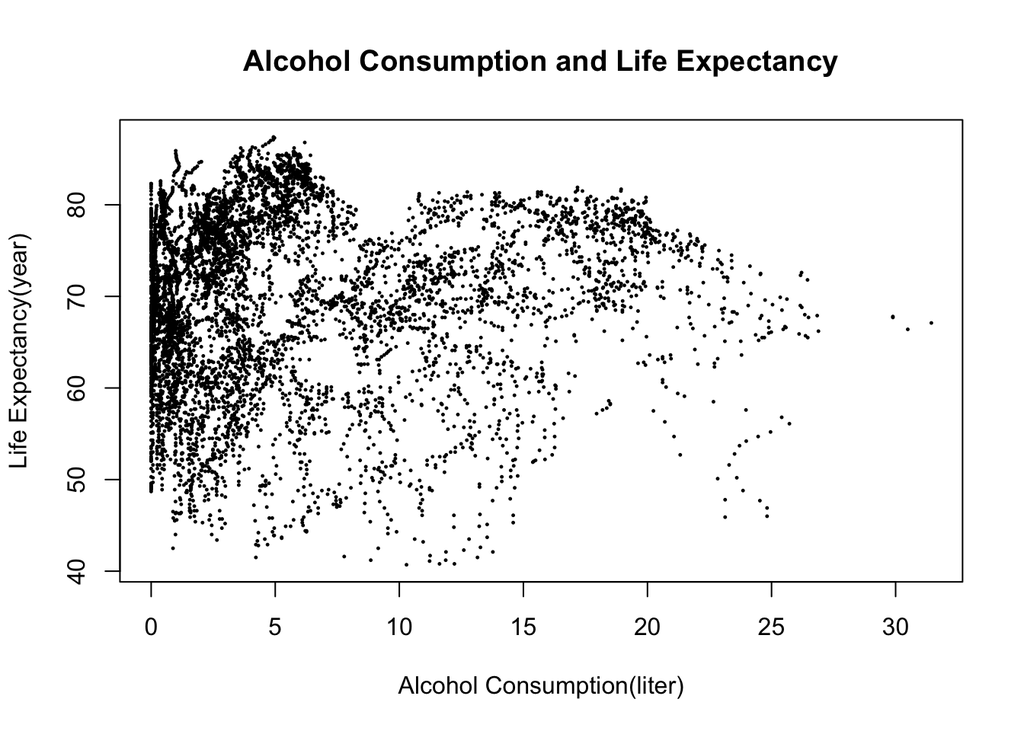

```r
plot(cleaned$Alcohol_Consumption, cleaned$Life_Expectancy, pch=19, cex=0.2,
     main = "Alcohol Consumption and Life Expectancy",
     xlab = "Alcohol Consumption(liter)", ylab = "Life Expectancy(year)")
```

```r
cor(cleaned$Life_Expectancy, cleaned$Alcohol_Consumption)
```

```
## [1] 0.08435437
```

Life expectancy and alcohol consumption are possitively correlated.

### 2. Does this association differ by Sex?

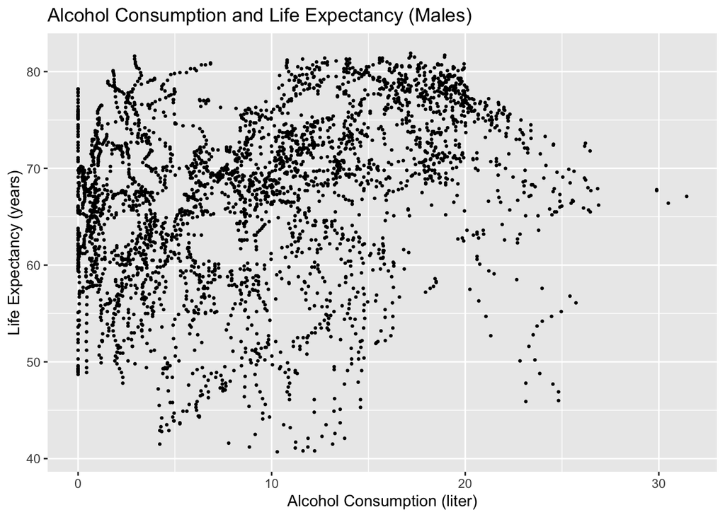

```r
cleaned %>%
  filter(Sex == "Male") %>%
  ggplot(aes(x = Alcohol_Consumption, y = Life_Expectancy)) +
  geom_point(shape = 19, size = 0.5) +
  labs(
    title = "Alcohol Consumption and Life Expectancy (Males)",
    x = "Alcohol Consumption (liter)",
    y = "Life Expectancy (years)"
  )
```

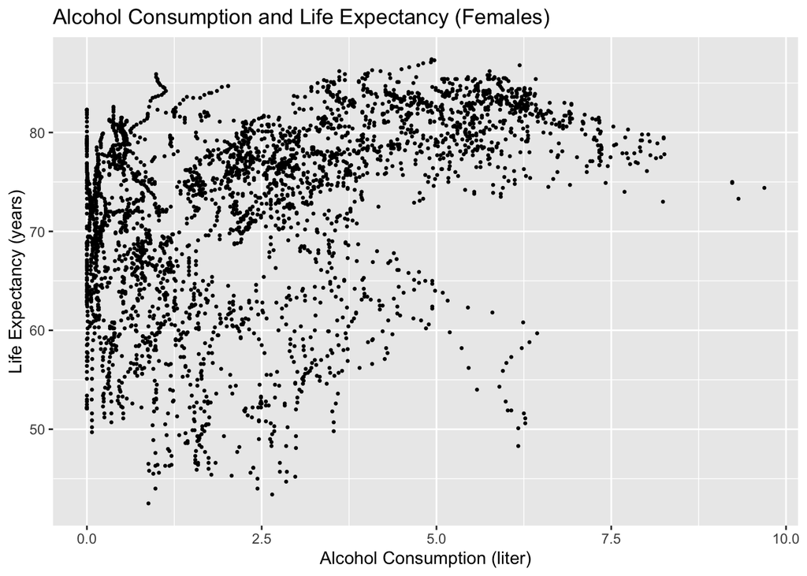

```r
cleaned %>%
  filter(Sex == "Female") %>%
  ggplot(aes(x = Alcohol_Consumption, y = Life_Expectancy)) +
  geom_point(shape = 19, size = 0.5) +
  labs(
    title = "Alcohol Consumption and Life Expectancy (Females)",
    x = "Alcohol Consumption (liter)",
    y = "Life Expectancy (years)"
  )
```

```r
cleaned %>%
  group_by(Sex) %>%
  summarise(cor = cor(Life_Expectancy, Alcohol_Consumption))
```

```
## # A tibble: 2 × 2
##   Sex      cor
##   <chr>  <dbl>
## 1 Female 0.438
## 2 Male   0.310
```

The correlation between life expectancy and alcohol consumption differs between males and females. Also, it shows that there is a stronger relationship between alcohol consumption and life expectancy within each sex category compared to the overall population.

### 3. How has life expectancy and alcohol consumption changed over time?

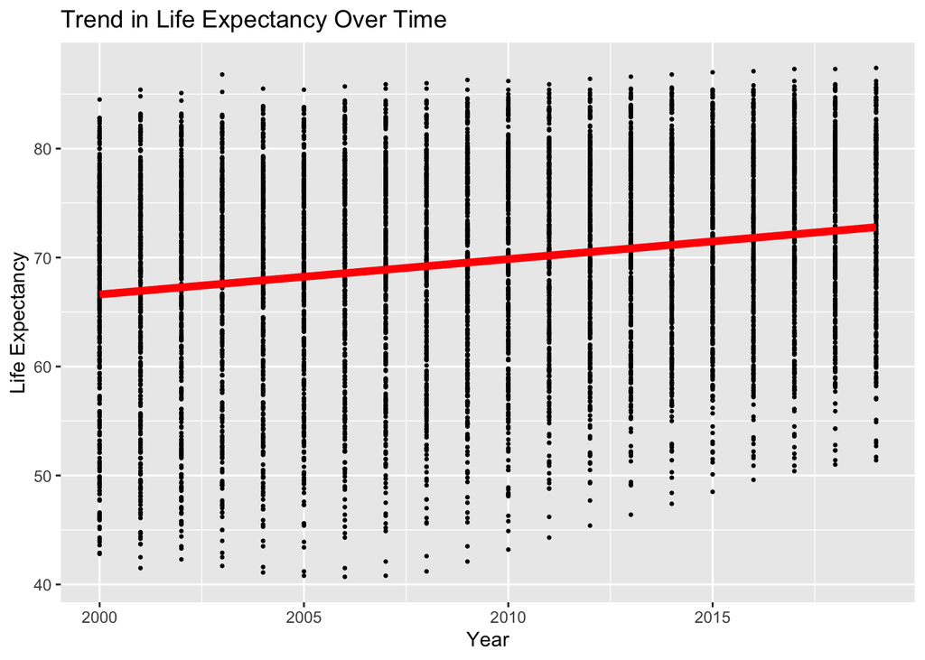

```r
cleaned %>%
  ggplot(aes(x = Year, y = Life_Expectancy)) +
  geom_point(shape = 19, size = 0.5) +
  geom_smooth(method = "lm", se = FALSE, lwd=2, col="red") +
  labs(title = "Trend in Life Expectancy Over Time", x = "Year", y = "Life Expectancy")
```

```r
le_summary <- cleaned %>%
  group_by(Year) %>%
  summarise(
    Mean_Life_Expectancy = mean(Life_Expectancy, na.rm = TRUE),
    Median_Life_Expectancy = median(Life_Expectancy, na.rm = TRUE),
    Min_Life_Expectancy = min(Life_Expectancy, na.rm = TRUE),
    Max_Life_Expectancy = max(Life_Expectancy, na.rm = TRUE),
    SD_Life_Expectancy = sd(Life_Expectancy, na.rm = TRUE)
  )
```

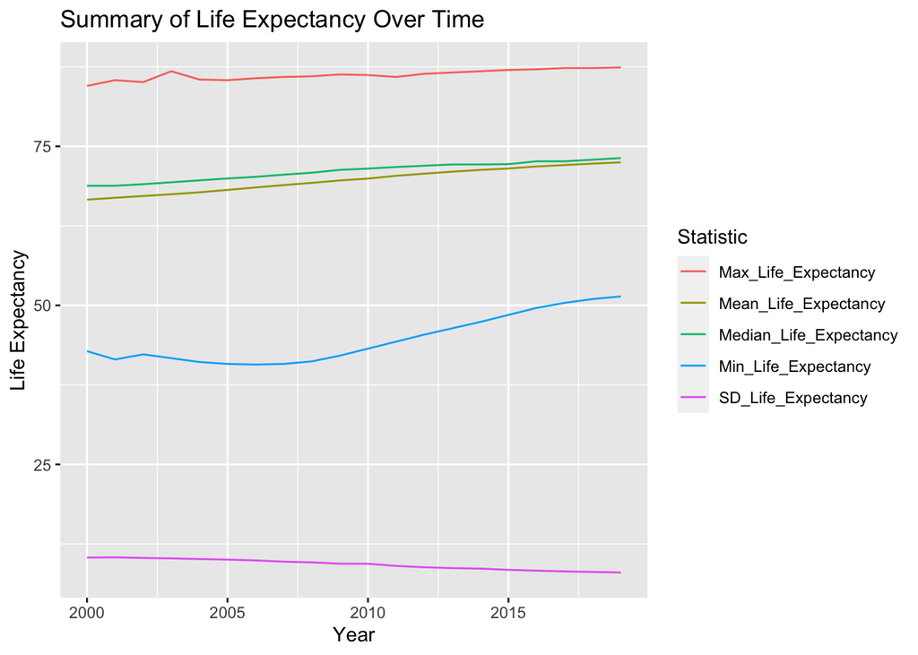

```r
le_summary_long <- pivot_longer(le_summary, cols = -c(Year), names_to = "Statistic")

ggplot(le_summary_long, aes(x = Year, y = value, color = Statistic)) +
  geom_line() +
  labs(title = "Summary of Life Expectancy Over Time",
       x = "Year",
       y = "Life Expectancy",
       color = "Statistic",
       linetype = "Statistic")
```

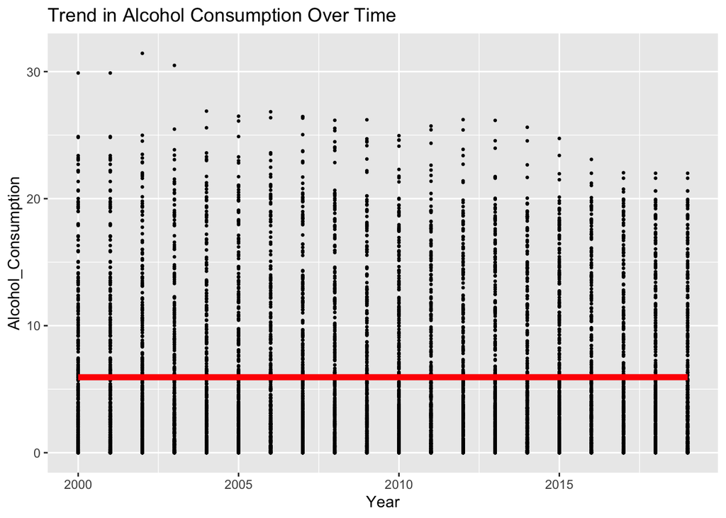

```r
cleaned %>%
  ggplot(aes(x = Year, y = Alcohol_Consumption)) +
  geom_point(shape = 19, size = 0.5) +
  geom_smooth(method = "lm", se = FALSE, lwd=2, col="red") +
  labs(title = "Trend in Alcohol Consumption Over Time", x = "Year", y = "Alcohol_Consumption")
```

```r
ac_summary <- cleaned %>%
  group_by(Year) %>%
  summarise(
    Mean_Alcohol_Consumption = mean(Alcohol_Consumption, na.rm = TRUE),
    Median_Alcohol_Consumption = median(Alcohol_Consumption, na.rm = TRUE),
    Min_Alcohol_Consumption = min(Alcohol_Consumption, na.rm = TRUE),
    Max_Alcohol_Consumption = max(Alcohol_Consumption, na.rm = TRUE),
    SD_Alcohol_Consumption = sd(Alcohol_Consumption, na.rm = TRUE)
  )
```

[figure not shown]

```r
ac_summary_long <- pivot_longer(ac_summary, cols = -c(Year), names_to = "Statistic")

ggplot(ac_summary_long, aes(x = Year, y = value, color = Statistic)) +
  geom_line() +
  labs(title = "Summary of Life Expectancy Over Time",
       x = "Year",
       y = "Alcohol_Consumption",
       color = "Statistic",
       linetype = "Statistic")
```

The mean/median/max/min life expectancy all increase over time, but the mean/median/min alcohol consumption remains about the same, only the max alcohol consumption decreases.

## Visualization

### 1. Stacked histogram of alcohol consumption by sex. Use different color schemes and transparancies so you can see both distributions.

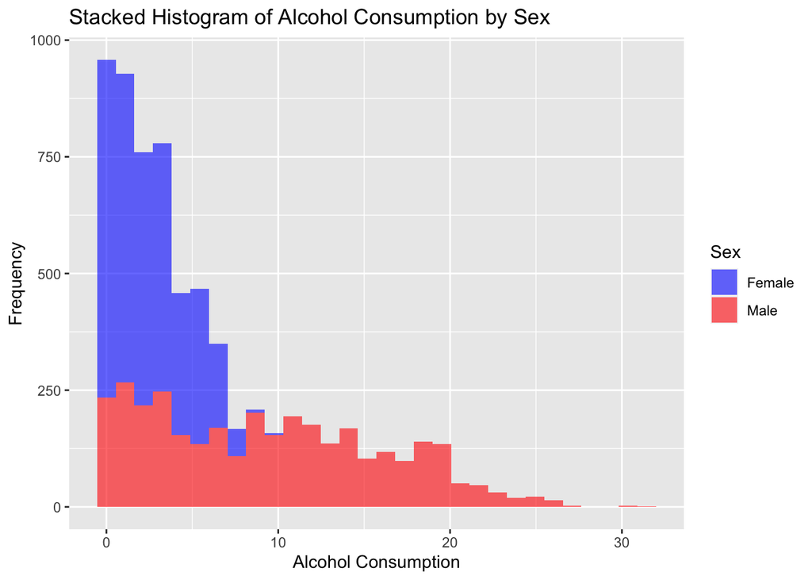

```r
ggplot(cleaned, aes(x = Alcohol_Consumption, fill = Sex)) +
  geom_histogram(position = "stack", alpha = 0.6) +
  labs(title = "Stacked Histogram of Alcohol Consumption by Sex",
       x = "Alcohol Consumption",
       y = "Frequency",
       fill = "Sex") +
  scale_fill_manual(values = c("Female" = "blue", "Male" = "red"))
```

### 2. Facet plot by year for 2000, 2010, and 2019 showing scatterplots with linear regression lines of life expectancy and alcohol consumption

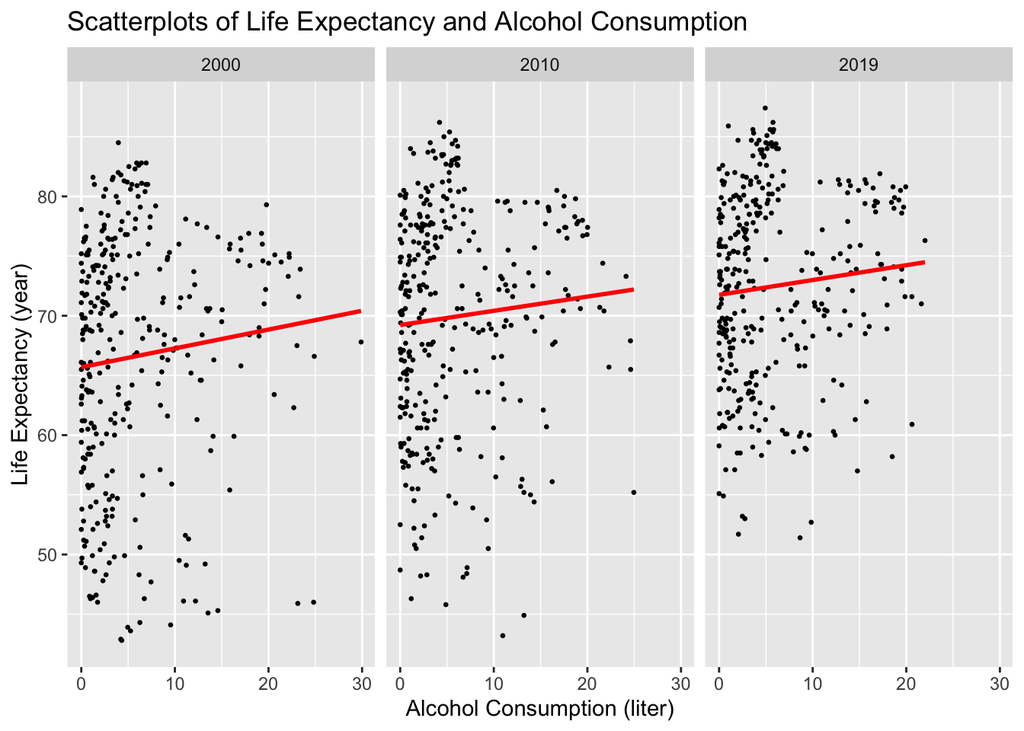

```r
filtered_data <- cleaned %>% filter(Year %in% c(2000, 2010, 2019))

ggplot(filtered_data, aes(x = Alcohol_Consumption, y = Life_Expectancy)) +
  geom_point(shape = 19, size = 0.5) +
  geom_smooth(method = "lm", se = FALSE, color = "red") +
  facet_wrap(~ Year, nrow = 1) +
  labs(title = "Scatterplots of Life Expectancy and Alcohol Consumption",
       x = "Alcohol Consumption (liter)",
       y = "Life Expectancy (year)")
```

On each of the three years, life expectancy is expected to increase as alcohol consumotion increases.

### 3. A linear model of life expectancy as a function of time, adjusted for sex. Compare the summary for Canada, and a second country of your choice.

```r
lm_canada <- lm(Life_Expectancy ~ Year + Sex, data = cleaned %>% filter(Country == "Canada"))
summary(lm_canada)
```

```
##
## Call:
## lm(formula = Life_Expectancy ~ Year + Sex, data = cleaned %>%
##     filter(Country == "Canada"))
##
## Residuals:
##      Min       1Q   Median       3Q      Max
## -0.53566 -0.17599  0.03276  0.18809  0.46039
##
## Coefficients:
##               Estimate Std. Error t value Pr(>|t|)
## (Intercept) -2.621e+02  1.472e+01  -17.81   <2e-16 ***
## Year         1.718e-01  7.326e-03   23.46   <2e-16 ***
## SexMale     -4.465e+00  8.449e-02  -52.85   <2e-16 ***
## ---
## Signif. codes:  0 '***' 0.001 '**' 0.01 '*' 0.05 '.' 0.1 ' ' 1
##
## Residual standard error: 0.2672 on 37 degrees of freedom
## Multiple R-squared:  0.9891, Adjusted R-squared:  0.9885
## F-statistic:  1672 on 2 and 37 DF,  p-value: < 2.2e-16
```

```r
lm_australia <- lm(Life_Expectancy ~ Year + Sex, data = cleaned %>% filter(Country == "Australia"))
summary(lm_australia)
```

```
##
## Call:
## lm(formula = Life_Expectancy ~ Year + Sex, data = cleaned %>%
##     filter(Country == "Australia"))
##
## Residuals:
##      Min       1Q   Median       3Q      Max
## -0.77357 -0.15961  0.08906  0.19321  0.40094
##
## Coefficients:
##               Estimate Std. Error t value Pr(>|t|)
## (Intercept) -2.960e+02  1.629e+01  -18.17   <2e-16 ***
## Year         1.891e-01  8.107e-03   23.33   <2e-16 ***
## SexMale     -4.480e+00  9.349e-02  -47.92   <2e-16 ***
## ---
## Signif. codes:  0 '***' 0.001 '**' 0.01 '*' 0.05 '.' 0.1 ' ' 1
##
## Residual standard error: 0.2956 on 37 degrees of freedom
## Multiple R-squared:  0.9871, Adjusted R-squared:  0.9864
## F-statistic:  1420 on 2 and 37 DF,  p-value: < 2.2e-16
```

Both countries show a significant increase in life expectancy over time, while Australia has a slightly higher increasing rate than Canada. The impact of being male on life expectancy is about the same in both countries, which decreases the life expectancy for about 4.5 years compared to females. Both Sex and Year are significant in predicting the life expectancy. The two models have similar r-squared and adjusted r-squared values(Canada has slightly larger values), thus the models are similarly reliable.

### 4. A faceted barplot of male and female life expectancy for the 10 countries with largest discrepancies (between males and females) in 2000 and 2019.

```r
discrepancy <- cleaned %>%
  filter(Year %in% c(2000, 2019)) %>%
  select(Country, Year, Sex, Life_Expectancy) %>%
  pivot_wider(names_from = Sex, values_from = Life_Expectancy) %>%
  mutate(Discrepancy = abs(Male - Female)) %>%
  select(Country, Year, Discrepancy)
head(discrepancy)
```

```
## # A tibble: 6 × 3
##   Country       Year Discrepancy
##   <chr>        <int>       <dbl>
## 1 Bangladesh    2019        4.40
## 2 Kuwait        2019        4.10
## 3 Mauritania    2019        3.90
## 4 Saudi Arabia  2019        2.80
## 5 Somalia       2019        4
## 6 Afghanistan   2019        6.1
```

```r
top10_discrepancy <- discrepancy %>%
  filter(Year %in% c(2000, 2019)) %>%
  group_by(Year) %>%
  arrange(desc(Discrepancy)) %>%
  top_n(10, Discrepancy) %>%
  arrange(Year, desc(Discrepancy))
top10_discrepancy
```

```
## # A tibble: 20 × 3
## # Groups:   Year [2]
##    Country      Year Discrepancy
##    <chr>       <int>       <dbl>
##  1 Belarus      2000       11.8
##  2 Kazakhstan   2000       11.3
##  3 Latvia       2000       11.2
##  4 Ukraine      2000       11.2
##  5 Estonia      2000       11
##  6 Lithuania    2000       10.8
##  7 Seychelles   2000        9.5
##  8 Uruguay      2000        8.90
##  9 Sri Lanka    2000        8.90
## 10 El Salvador  2000        8.8
## 11 Belarus      2019       10.5
## 12 Ukraine      2019       10.4
## 13 Georgia      2019        9.9
## 14 Armenia      2019        9.5
## 15 Mongolia     2019        9.3
## 16 Lithuania    2019        9
## 17 Thailand     2019        8.80
## 18 El Salvador  2019        8.8
## 19 Latvia       2019        8.7
## 20 Tuvalu       2019        8.30
```

```r
top_data <- cleaned %>%
  group_by(Country, Year) %>%
  inner_join(top10_discrepancy, by = c("Country", "Year"))
top_data
```

```
## # A tibble: 40 × 8
## # Groups:   Country, Year [20]
##    Country      Year Sex   Alcohol_Consumption Life_Expectancy consumption_level
##    <chr>       <int> <chr>               <dbl>           <dbl> <chr>
##  1 Tuvalu       2019 Fema…                0.45            68.9 low
##  2 El Salvador  2019 Fema…                1.75            76.8 medium
##  3 Thailand     2019 Male                13.8             74.6 medium
##  4 Ukraine      2019 Male                14               69.2 medium
##  5 Georgia      2019 Male                15.6             68.5 high
##  6 Belarus      2019 Male                17.9             68.9 high
##  7 Armenia      2019 Fema…                2.14            79.9 medium
##  8 Tuvalu       2019 Male                 2.26            60.6 low
##  9 Mongolia     2019 Fema…                2.72            76.6 medium
## 10 Lithuania    2019 Male                20.6             71.6 high
## # ℹ 30 more rows
## # ℹ 2 more variables: Population_all <dbl>, Discrepancy <dbl>
```

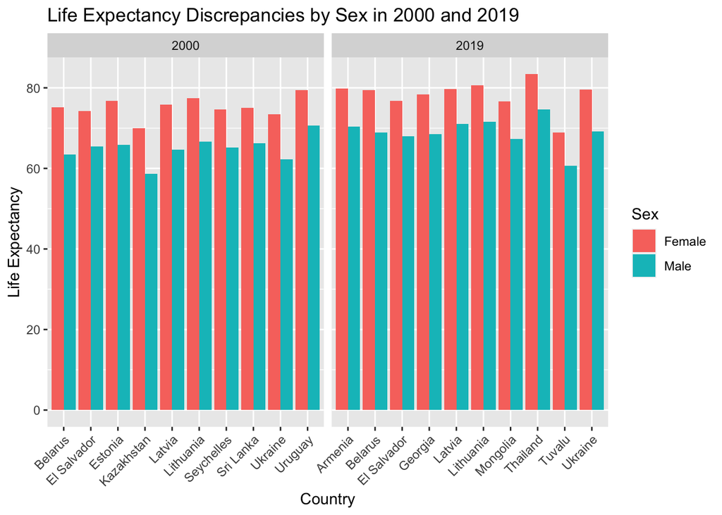

```r
ggplot(top_data, aes(x = Country, y = Life_Expectancy, fill = Sex)) +
  geom_bar(stat = "identity", position = "dodge") +
  facet_wrap(~Year, nrow = 1, scales = "free_x") +
  labs(title = "Life Expectancy Discrepancies by Sex in 2000 and 2019",
       x = "Country",
       y = "Life Expectancy") +
  theme(axis.text.x = element_text(angle = 45, hjust = 1))
```

In all countries with the top 10 largest discrepancies, females have a higher life expectancy than males for both years.

### 5. A boxplot of life expectancy by alcohol consumption level and sex for the year 2019.

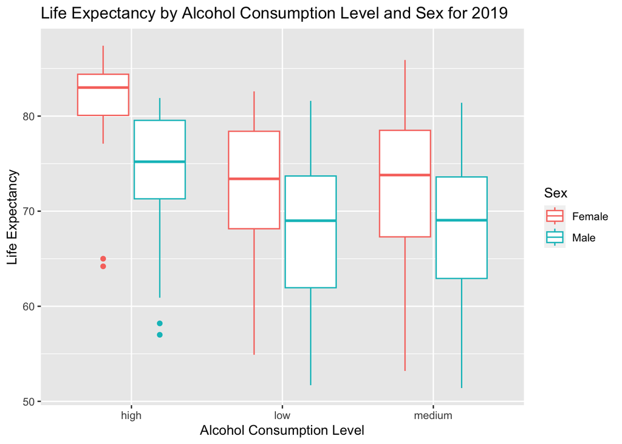

```r
ggplot(cleaned %>% filter(Year == 2019), aes(x = consumption_level, y = Life_Expectancy, color = Sex)) +
  geom_boxplot() +
  labs(title = "Life Expectancy by Alcohol Consumption Level and Sex for 2019",
       x = "Alcohol Consumption Level",
       y = "Life Expectancy")
```

### 6. Choose a visualization to examine the association life expectancy between males and females with alcohol consumption over time.

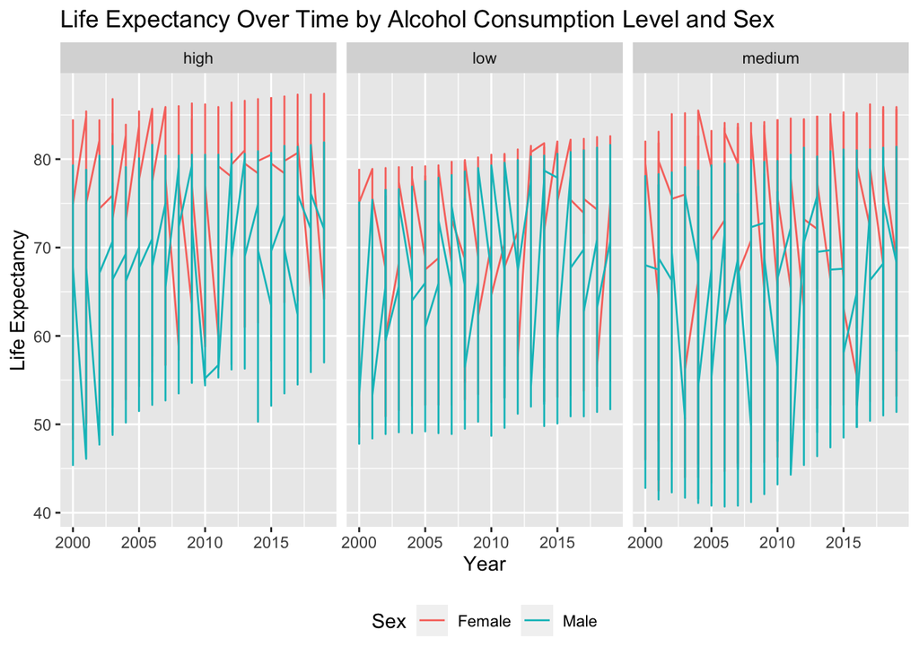

```r
ggplot(cleaned, aes(x = Year, y = Life_Expectancy, color = Sex, group = interaction(Sex, consumption_level))) +
  geom_line() +
  facet_wrap(~consumption_level) +
  labs(title = "Life Expectancy Over Time by Alcohol Consumption Level and Sex",
       x = "Year",
       y = "Life Expectancy",
       color = "Sex") +
  theme(legend.position = "bottom")
```

## Advanced Regression

Construct a multiple linear regression model to examine the association between life expectancy and alcohol consumption level adjusted for population, year, and sex. Note you may want to scale population since the values are so large. First use population as a linear predictor variable, and then fit another model where you put a cubic regression spline on population.

```r
scaled <- cleaned %>% mutate(Scaled_Population = scale(Population_all))
lm <- lm(Life_Expectancy ~ Alcohol_Consumption + Scaled_Population + Year + Sex, data = scaled)
gam <- gam(Life_Expectancy ~ Alcohol_Consumption + s(Scaled_Population, bs = "cr") + Year + Sex, data = scaled)
```

### 1. Provide summaries of your models, including overall model fit and interpretation of the parameter estimates (linear and non-linear).

```r
summary(lm)
```

```
##
## Call:
## lm(formula = Life_Expectancy ~ Alcohol_Consumption + Scaled_Population +
##     Year + Sex, data = scaled)
##
## Residuals:
##     Min      1Q  Median      3Q     Max
## -27.363  -5.298   2.097   6.229  16.300
##
## Coefficients:
##                       Estimate Std. Error t value Pr(>|t|)
## (Intercept)         -579.81512   36.40078  -15.93   <2e-16 ***
## Alcohol_Consumption    0.54960    0.02113   26.01   <2e-16 ***
## Scaled_Population      0.25592    0.10448    2.45   0.0143 *
## Year                   0.32378    0.01811   17.88   <2e-16 ***
## SexMale               -8.78894    0.25311  -34.72   <2e-16 ***
## ---
## Signif. codes:  0 '***' 0.001 '**' 0.01 '*' 0.05 '.' 0.1 ' ' 1
##
## Residual standard error: 8.536 on 6687 degrees of freedom
## Multiple R-squared:  0.1919, Adjusted R-squared:  0.1915
## F-statistic: 397.1 on 4 and 6687 DF,  p-value: < 2.2e-16
```

```r
summary(gam)
```

```
##
## Family: gaussian
## Link function: identity
##
## Formula:
## Life_Expectancy ~ Alcohol_Consumption + s(Scaled_Population,
##     bs = "cr") + Year + Sex
##
## Parametric coefficients:
##                       Estimate Std. Error t value Pr(>|t|)
## (Intercept)         -592.00074   34.89152  -16.97   <2e-16 ***
## Alcohol_Consumption    0.52377    0.02042   25.65   <2e-16 ***
## Year                   0.32988    0.01736   19.00   <2e-16 ***
## SexMale               -8.61383    0.24296  -35.45   <2e-16 ***
## ---
## Signif. codes:  0 '***' 0.001 '**' 0.01 '*' 0.05 '.' 0.1 ' ' 1
##
## Approximate significance of smooth terms:
##                        edf Ref.df     F p-value
## s(Scaled_Population) 8.987      9 69.91  <2e-16 ***
## ---
## Signif. codes:  0 '***' 0.001 '**' 0.01 '*' 0.05 '.' 0.1 ' ' 1
##
## R-sq.(adj) =   0.26   Deviance explained = 26.1%
## GCV = 66.835  Scale est. = 66.705    n = 6692
```

### 2. Plot the smooth (gam) model and interpret.

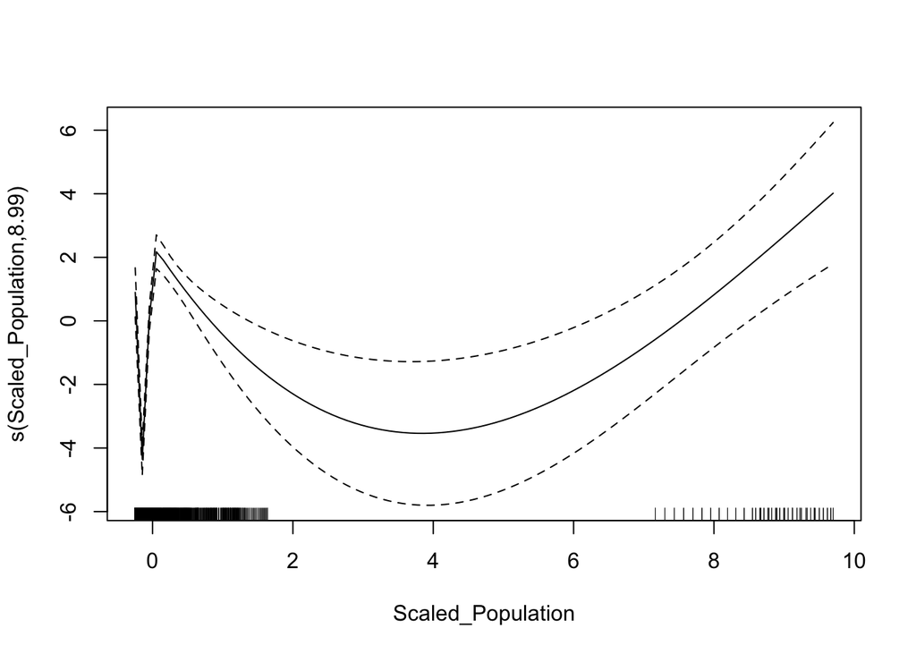

```r
plot(gam)
```

### 3. Take the average alcohol consumption and life expectancy by country and sex (i.e. remove time). Re-run the same two regressions (except without year), summarize and interpret.

```r
average_data <- scaled %>%
  group_by(Country, Sex) %>%
  summarise(Average_AC = mean(Alcohol_Consumption, na.rm = TRUE),
            Average_LE = mean(Life_Expectancy, na.rm = TRUE),
            Average_SP = mean(Scaled_Population, na.rm = TRUE),
            .groups = "drop")
head(average_data)
```

```
## # A tibble: 6 × 5
##   Country     Sex    Average_AC Average_LE Average_SP
##   <chr>       <chr>       <dbl>      <dbl>      <dbl>
## 1 Afghanistan Female     0.0063       62.0   -0.0485
## 2 Afghanistan Male       0.0430       58.4   -0.0485
## 3 Albania     Female     2.72         80.3   -0.226
## 4 Albania     Male      11.5          75.1   -0.226
## 5 Algeria     Female     0.128        74.7    0.00523
## 6 Algeria     Male       0.814        72.4    0.00523
```

```r
lm_avg <- lm(Average_LE ~ Average_AC + Average_SP + Sex, data = average_data)
gam_avg <- gam(Average_LE ~ Average_AC + s(Average_SP, bs = "cr") + Sex, data = average_data)

summary(lm_avg)
```

```
##
## Call:
## lm(formula = Average_LE ~ Average_AC + Average_SP + Sex, data = average_data)
##
## Residuals:
##     Min      1Q  Median      3Q     Max
## -22.723  -5.392   2.082   6.152  15.460
##
## Coefficients:
##             Estimate Std. Error t value Pr(>|t|)
## (Intercept) 70.78784    0.69475 101.889  < 2e-16 ***
## Average_AC   0.57544    0.09502   6.056 3.77e-09 ***
## Average_SP   0.25689    0.46252   0.555    0.579
## SexMale     -8.98373    1.12470  -7.988 2.28e-14 ***
## ---
## Signif. codes:  0 '***' 0.001 '**' 0.01 '*' 0.05 '.' 0.1 ' ' 1
##
## Residual standard error: 8.433 on 332 degrees of freedom
## Multiple R-squared:  0.1681, Adjusted R-squared:  0.1605
## F-statistic: 22.36 on 3 and 332 DF,  p-value: 3.294e-13
```

```r
summary(gam_avg)
```

```
##
## Family: gaussian
## Link function: identity
##
## Formula:
## Average_LE ~ Average_AC + s(Average_SP, bs = "cr") + Sex
##
## Parametric coefficients:
##             Estimate Std. Error t value Pr(>|t|)
## (Intercept) 70.86395    0.66940 105.862  < 2e-16 ***
## Average_AC   0.54568    0.09242   5.905 8.91e-09 ***
## SexMale     -8.78114    1.08608  -8.085 1.25e-14 ***
## ---
## Signif. codes:  0 '***' 0.001 '**' 0.01 '*' 0.05 '.' 0.1 ' ' 1
##
## Approximate significance of smooth terms:
##                 edf Ref.df     F  p-value
## s(Average_SP) 8.672  8.914 3.599 0.000209 ***
## ---
## Signif. codes:  0 '***' 0.001 '**' 0.01 '*' 0.05 '.' 0.1 ' ' 1
##
## R-sq.(adj) =  0.223   Deviance explained = 24.8%
## GCV = 68.207  Scale est. = 65.837    n = 336
```

### 4. Make a plot average alcohol consumption and life expectancy and color by sex. Add a linear regression line and a smooth regression line.

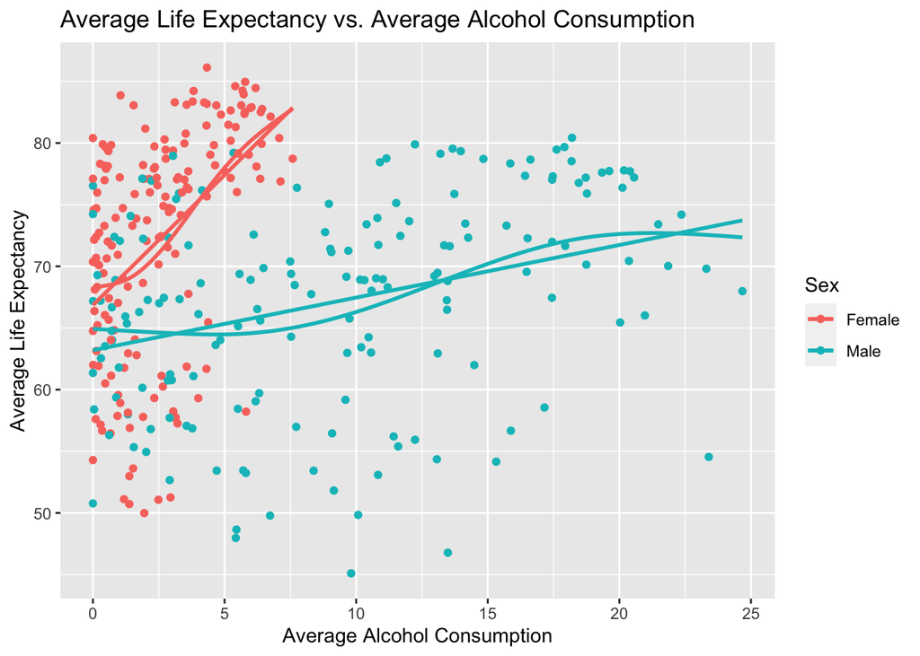

```r
ggplot(average_data, aes(x = Average_AC, y = Average_LE, color = Sex)) +
  geom_point() +
  geom_smooth(method = "lm", se = FALSE) +
  geom_smooth(method = "gam", formula = y ~ s(x, bs = "cs"), se = FALSE) +
  labs(title = "Average Life Expectancy vs. Average Alcohol Consumption",
       x = "Average Alcohol Consumption",
       y = "Average Life Expectancy")
```